# INNER JOIN

The INNER JOIN keyword selects records that have matching values in both tables.

Syntax SELECT column_name(s) FROM table1 INNER JOIN table2 ON table1.column_name = table2.column_name;

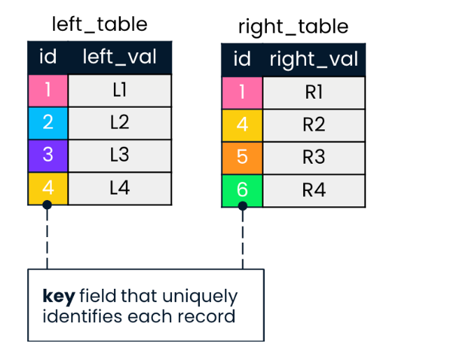

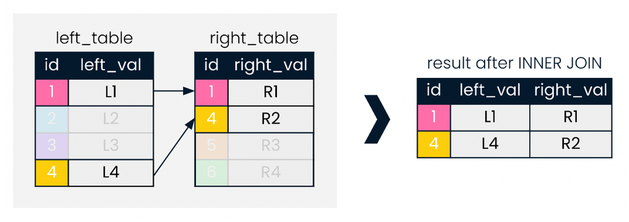

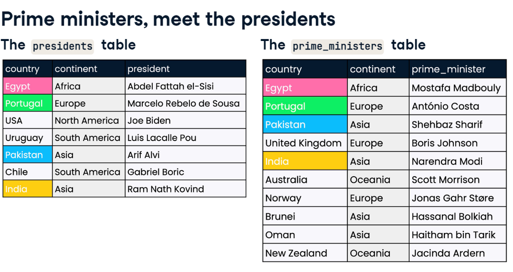

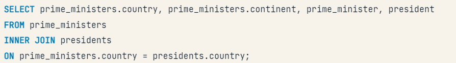

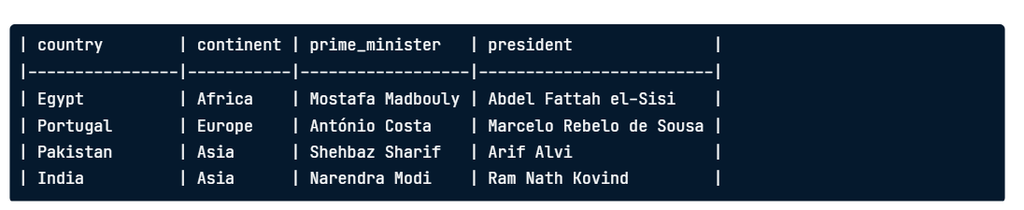

### Example

Using Database World,use the cities and countries tables to build your first inner join. Guide:

- Identify the relevant column names to join ON by inspecting the cities and countries
- Perform an inner join with the cities table on the left and the countries table on the right;
- Keep only the name of the city, the name of the country, and the region the country is locate in using the SELECT statement.
- Alias the name of the city AS city and the name of the country AS country

SELECT cities.name AS city, countries.name AS country, region FROM cities INNER JOIN countries ON cities.country_code = countries.code;

## Exercise

- Write an SQL Query that joins tables country and economies where there are matching values on both tables.
- Use an alieas name for countries as c and economies as e
- Keep only the name of the code from the countries table (alias it as country_code), name, year, and inflation_rate.

SELECT c.code AS country_code, name, year, inflation_rate FROM countries AS c INNER JOIN economies AS e ON c.code = e.code;

# LEFT JOIN

The LEFT JOIN keyword returns all records from the left table (table1), and the matching records from the right table (table2). The result is 0 records from the right side, if there is no match.

In some databases LEFT JOIN is called LEFT OUTER JOIN.

Syntax SELECT column_name(s) FROM table1 LEFT JOIN table2 ON table1.column_name = table2.column_name;

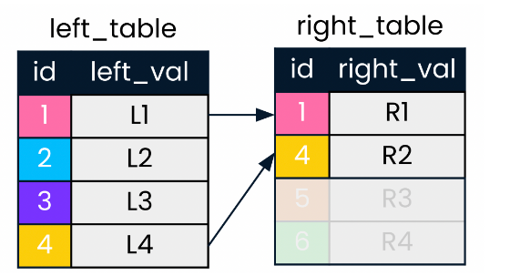

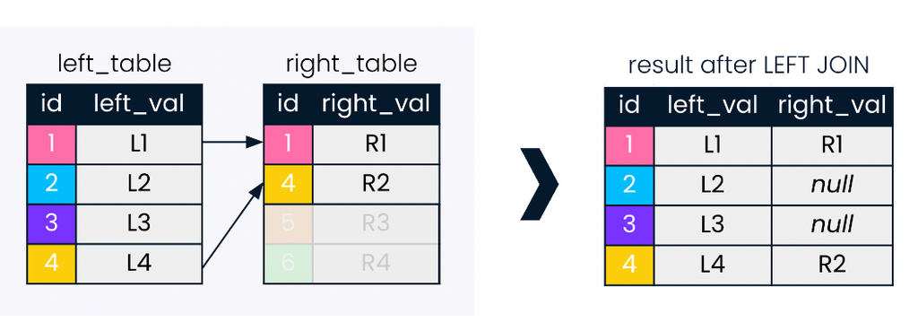

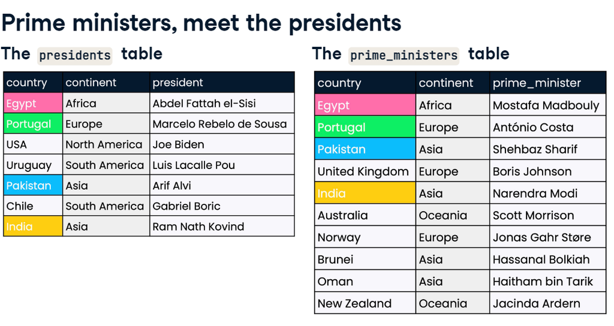

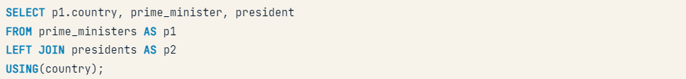

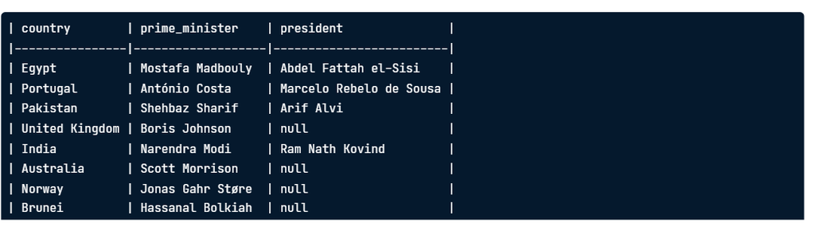

# RIGHT JOIN

The RIGHT JOIN keyword returns all records from the right table (table2), and the matching records from the left table (table1). The result is 0 records from the left side, if there is no match.

In some databases RIGHT JOIN is called RIGHT OUTER JOIN.

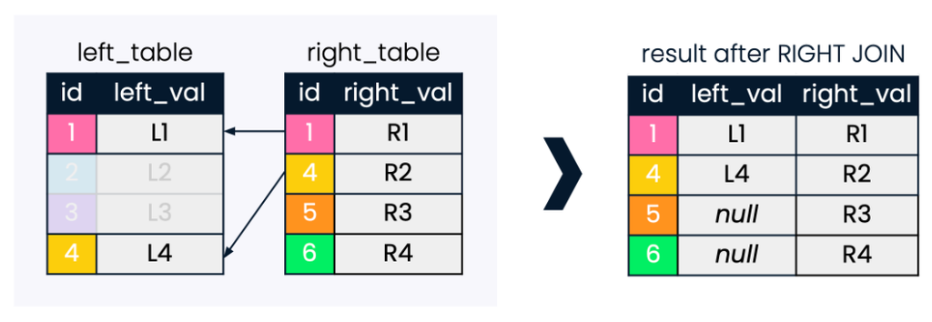

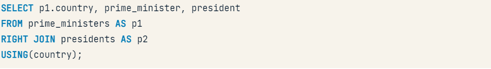

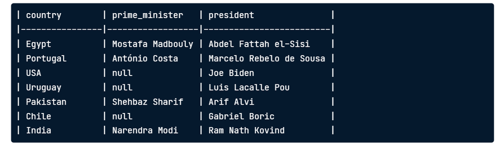

## Exercise

SELECT c1.name AS city, code, c2.name AS country, region, city_proper_pop FROM cities AS c1 LEFT JOIN countries as c2 ON c1.country_code = c2.code ORDER BY code DESC;

## Full JOIN

The FULL OUTER JOIN keyword returns all records when there is a match in left (table1) or right (table2) table records.

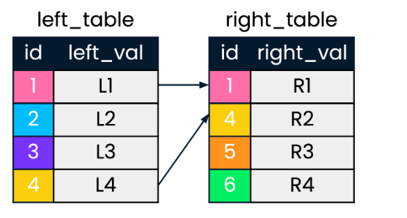

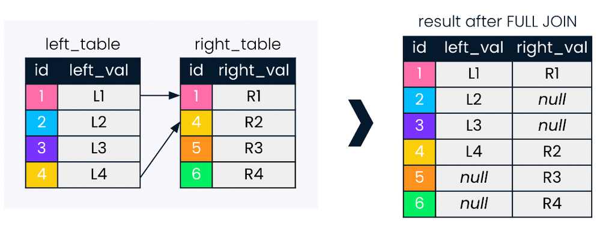

Syntax

SELECT column_name(s) FROM table1 FULL OUTER JOIN table2 ON table1.column_name = table2.column_name WHERE condition;

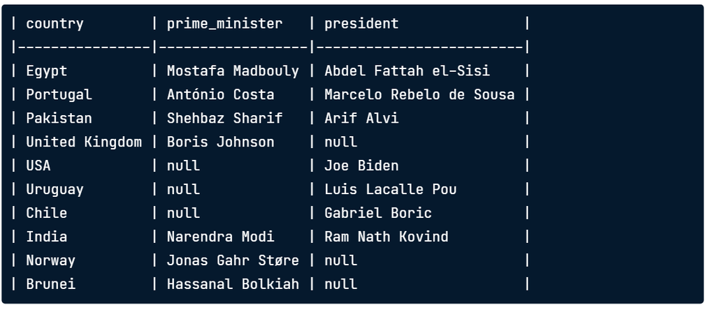

## Exercise

- Perform a full join with countries (left) and currencies (right).
- Filter for the North America region or NULL country names.
- Order by region

SELECT name AS country, code, region, basic_unit FROM countries -- Join to currencies FULL JOIN currencies USING (code) -- Where region is North America or null WHERE region = 'North America' OR name IS NULL ORDER BY region;